# Chapter 7 Multiple Regression II

Bryan Goodrich

2015-08-08

# Chapter 7 – Multiple Regression II

## Load the data sets

```r
data("CH07TA01", package = "ALSM")
data("CH06FI05", package = "ALSM")
data("CH07TA06", package = "ALSM")
```

## Input the Body Fat Data

```r
.data <- CH07TA01
names(.data) <- c("x1", "x2", "x3", "y")
fit <- lm(y ~ x1 + x2 + x3, .data)
```

## TABLE 7.1 (p 257)

#### Basic Data–Body Fat Example

```r
with(.data, cbind("Triceps"  = x1,
               "Thigh"    = x2,
               "Midarm"   = x3,
               "Body Fat" = y))
```

```
##       Triceps Thigh Midarm Body Fat
##  [1,]    19.5  43.1   29.1     11.9
##  [2,]    24.7  49.8   28.2     22.8
##  [3,]    30.7  51.9   37.0     18.7
##  [4,]    29.8  54.3   31.1     20.1
##  [5,]    19.1  42.2   30.9     12.9
##  [6,]    25.6  53.9   23.7     21.7
##  [7,]    31.4  58.5   27.6     27.1
##  [8,]    27.9  52.1   30.6     25.4
##  [9,]    22.1  49.9   23.2     21.3
## [10,]    25.5  53.5   24.8     19.3
## [11,]    31.1  56.6   30.0     25.4
## [12,]    30.4  56.7   28.3     27.2
## [13,]    18.7  46.5   23.0     11.7
## [14,]    19.7  44.2   28.6     17.8
## [15,]    14.6  42.7   21.3     12.8
## [16,]    29.5  54.4   30.1     23.9
## [17,]    27.7  55.3   25.7     22.6
## [18,]    30.2  58.6   24.6     25.4
## [19,]    22.7  48.2   27.1     14.8
## [20,]    25.2  51.0   27.5     21.1
```

## TABLE 7.2 (p 257)

#### Regression Results for Several Fitted Models–Body Fat Example

One thing to realize with R ANOVA results is that it doesn’t give you an SSR for the entire regression. Instead, it gives you the sum of squares for the first term in the model, then the extra from the addition of the second term, and so on. With their example of `y ~ x1 + x2` we have `SSR = 385.44`; however, the ANOVA results provided would need to be aggregated to obtain that answer. Therefore, what we require is:

> `SSR(x1) + SSR(x2|x1) = 352.27 + 33.17 = 385.44 = SSR(x1, x2)`

So be aware that the R ANOVA results provide the extra SS directly, depending on how the terms were entered into the model.

```r
summary(lm(y ~ x1, .data))
```

```
##
## Call:
## lm(formula = y ~ x1, data = .data)
##
## Residuals:
##    Min     1Q Median     3Q    Max
## -6.120 -2.190  0.674  1.938  3.852
##
## Coefficients:
##             Estimate Std. Error t value Pr(>|t|)
## (Intercept)   -1.496      3.319   -0.45     0.66
## x1             0.857      0.129    6.66 0.000003 ***
## ---
## Signif. codes:  0 '***' 0.001 '**' 0.01 '*' 0.05 '.' 0.1 ' ' 1
##
## Residual standard error: 2.82 on 18 degrees of freedom
## Multiple R-squared:  0.711,  Adjusted R-squared:  0.695
## F-statistic: 44.3 on 1 and 18 DF,  p-value: 0.00000302
```

```r
anova(lm(y ~ x1, .data))
```

```
## Analysis of Variance Table
##
## Response: y
##           Df Sum Sq Mean Sq F value   Pr(>F)
## x1         1    352     352    44.3 0.000003 ***
## Residuals 18    143       8
## ---
## Signif. codes:  0 '***' 0.001 '**' 0.01 '*' 0.05 '.' 0.1 ' ' 1
```

```r
summary(lm(y ~ x2, .data))
```

```
##
## Call:
## lm(formula = y ~ x2, data = .data)
##
## Residuals:
##    Min     1Q Median     3Q    Max
## -4.495 -1.567  0.124  1.336  4.408
##
## Coefficients:
##             Estimate Std. Error t value   Pr(>|t|)
## (Intercept)  -23.634      5.657   -4.18    0.00057 ***
## x2             0.857      0.110    7.79 0.00000036 ***
## ---
## Signif. codes:  0 '***' 0.001 '**' 0.01 '*' 0.05 '.' 0.1 ' ' 1
##
## Residual standard error: 2.51 on 18 degrees of freedom
## Multiple R-squared:  0.771,  Adjusted R-squared:  0.758
## F-statistic: 60.6 on 1 and 18 DF,  p-value: 0.00000036
```

```r
anova(lm(y ~ x2, .data))
```

```
## Analysis of Variance Table
##
## Response: y
##           Df Sum Sq Mean Sq F value     Pr(>F)
## x2         1    382     382    60.6 0.00000036 ***
## Residuals 18    113       6
## ---
## Signif. codes:  0 '***' 0.001 '**' 0.01 '*' 0.05 '.' 0.1 ' ' 1
```

```r
summary(lm(y ~ x1 + x2, .data))
```

```
##
## Call:
## lm(formula = y ~ x1 + x2, data = .data)
##
## Residuals:
##    Min     1Q Median     3Q    Max
## -3.947 -1.881  0.168  1.337  4.015
##
## Coefficients:
##             Estimate Std. Error t value Pr(>|t|)
## (Intercept)  -19.174      8.361   -2.29    0.035 *
## x1             0.222      0.303    0.73    0.474
## x2             0.659      0.291    2.26    0.037 *
## ---
## Signif. codes:  0 '***' 0.001 '**' 0.01 '*' 0.05 '.' 0.1 ' ' 1
##
## Residual standard error: 2.54 on 17 degrees of freedom
## Multiple R-squared:  0.778,  Adjusted R-squared:  0.752
## F-statistic: 29.8 on 2 and 17 DF,  p-value: 0.00000277
```

```r
anova(lm(y ~ x1 + x2, .data))
```

```
## Analysis of Variance Table
##
## Response: y
##           Df Sum Sq Mean Sq F value    Pr(>F)
## x1         1    352     352   54.47 0.0000011 ***
## x2         1     33      33    5.13     0.037 *
## Residuals 17    110       6
## ---
## Signif. codes:  0 '***' 0.001 '**' 0.01 '*' 0.05 '.' 0.1 ' ' 1
```

```r
summary(fit)
```

```
##
## Call:
## lm(formula = y ~ x1 + x2 + x3, data = .data)
##
## Residuals:
##    Min     1Q Median     3Q    Max
## -3.726 -1.611  0.392  1.466  4.128
##
## Coefficients:
##             Estimate Std. Error t value Pr(>|t|)
## (Intercept)   117.08      99.78    1.17     0.26
## x1              4.33       3.02    1.44     0.17
## x2             -2.86       2.58   -1.11     0.28
## x3             -2.19       1.60   -1.37     0.19
##
## Residual standard error: 2.48 on 16 degrees of freedom
## Multiple R-squared:  0.801,  Adjusted R-squared:  0.764
## F-statistic: 21.5 on 3 and 16 DF,  p-value: 0.00000734
```

```r
anova(fit)
```

```
## Analysis of Variance Table
##
## Response: y
##           Df Sum Sq Mean Sq F value    Pr(>F)
## x1         1    352     352   57.28 0.0000011 ***
## x2         1     33      33    5.39     0.034 *
## x3         1     12      12    1.88     0.190
## Residuals 16     98       6
## ---
## Signif. codes:  0 '***' 0.001 '**' 0.01 '*' 0.05 '.' 0.1 ' ' 1
```

## TABLE 7.4 (p 262)

#### ANOVA Table with Decomposition of SSR–Body Fat Example

For numeric subscripting, the following will be utilized

```
   Number    Rows                      Columns
   1         x1        (x1)            Df
   2         x2        (x2 | x1)       Sum Sq
   3         x3        (x3 | x1, x2)   Mean Sq
   4         Residuals (pure error)
```

The code below compiles each column row-wise. Naming is only required for each record once, but indentation is provided for clarity.

```r
fit.aov <- anova(fit)
tab <- as.table(cbind(
  'SS' = c("SSR(x1, x2, x3)" = sum(fit.aov[1:3, 2]),
         "SSR(x1)"           = fit.aov[1, 2],
         "SSR(x2|x1)"        = fit.aov[2, 2],
         "SSR(x3|x1, x2)"    = fit.aov[3, 2],
         "SSE"               = fit.aov[4, 2],
         "Total"             = sum(fit.aov[, 2])),

  'Df' = c(                    sum(fit.aov[1:3, 1]),
                               fit.aov[1, 1],
                               fit.aov[2, 1],
                               fit.aov[3, 1],
                               fit.aov[4, 1],
                               sum(fit.aov$Df)),

  'MS' = c(                    sum(fit.aov[1:3, 2]) / sum(fit.aov[1:3, 1]),
                               fit.aov[1, 3],
                               fit.aov[2, 3],
                               fit.aov[3, 3],
                               fit.aov[4, 3],
                               NA)
))

round(tab, 2)
```

```
##                     SS     Df     MS
## SSR(x1, x2, x3) 396.98   3.00 132.33
## SSR(x1)         352.27   1.00 352.27
## SSR(x2|x1)       33.17   1.00  33.17
## SSR(x3|x1, x2)   11.55   1.00  11.55
## SSE              98.40  16.00   6.15
## Total           495.39  19.00
```

## Uses of Extra Sums of Squares in Tests for Regression Coefficients (p 264)

#### Test Whether A Single Coefficient Can Be Dropped (i.e., bk = 0)

Since the above example demonstrates how to extract each of the components in an extra SS analysis, I will assume the reader can figure out how to compute the arithmetic with those components. Instead, here will be two ways to perform the same analysis. The `anova` function can compare models in precisely this way. R also has the `drop1` that does the same test for each of possible “drop 1 term” models.

```r
anova(update(fit, . ~ . - x3), fit)  # the "." indicates "old model terms"
```

```
## Analysis of Variance Table
##
## Model 1: y ~ x1 + x2
## Model 2: y ~ x1 + x2 + x3
##   Res.Df   RSS Df Sum of Sq    F Pr(>F)
## 1     17 110.0
## 2     16  98.4  1      11.6 1.88   0.19
```

```r
drop1(fit, test = "F")               # Alternative for each term
```

```
## Single term deletions
##
## Model:
## y ~ x1 + x2 + x3
##        Df Sum of Sq   RSS  AIC F value Pr(>F)
## <none>               98.4 39.9
## x1      1     12.70 111.1 40.3    2.07   0.17
## x2      1      7.53 105.9 39.3    1.22   0.28
## x3      1     11.55 110.0 40.1    1.88   0.19
```

## Uses of Extra Sums of Squares in Tests for Regression Coefficients (p 265)

#### Test Whether Several Coefficients Can Be Dropped

```r
anova(lm(y ~ x1, .data), fit)
```

```
## Analysis of Variance Table
##
## Model 1: y ~ x1
## Model 2: y ~ x1 + x2 + x3
##   Res.Df   RSS Df Sum of Sq    F Pr(>F)
## 1     18 143.1
## 2     16  98.4  2      44.7 3.64   0.05 *
## ---
## Signif. codes:  0 '***' 0.001 '**' 0.01 '*' 0.05 '.' 0.1 ' ' 1
```

## Coefficients of Partial Determination and Correlation (p 270-1)

```r
sign.1 <- sign(coef(lm(y ~ x1 + x2, .data)))[["x1"]]
sign.2 <- sign(coef(lm(y ~ x1 + x2, .data)))[["x2"]]
sign.3 <- sign(coef(fit))[["x3"]]

rbind(
  "2|1"  =  c("Rsq" = anova(fit)["x2", 2] / anova(lm(y ~ x1, .data))["Residuals", 2],
              "r"   = sign.2 * sqrt(anova(fit)["x2", 2] / anova(lm(y ~ x1, .data))["Residuals", 2])),

  "3|12" = c(         anova(fit)["x3", 2] / anova(lm(y ~ x1 + x2, .data))["Residuals", 2],
                      sign.3 * sqrt(anova(fit)["x3", 2] / anova(lm(y ~ x1 + x2, .data))["Residuals", 2])),

  "1|2"  = c(         anova(lm(y ~ x2 + x1, .data))["x1", 2] / anova(lm(y ~ x2, .data))["Residuals", 2],
                      sign.1 * sqrt(anova(lm(y ~ x2 + x1, .data))["x1", 2] / anova(lm(y ~ x2, .data))["Residuals", 2]))
)
```

```
##          Rsq       r
## 2|1  0.23176  0.4814
## 3|12 0.10501 -0.3241
## 1|2  0.03062  0.1750
```

## Input the Dwaine Studios Data

```r
.data <- CH06FI05
names(.data) <- c("x1", "x2", "y")
```

## TABLE 7.5 (pp 276-7)

#### Correlation Transformation and Fitted Standardized Regression Model–Dwaine Studios Example

```r
with(.data, cbind(Sales = y, Population = x1, Income = x2))  # Table 7.5(a)
```

```
##       Sales Population Income
##  [1,] 174.4       68.5   16.7
##  [2,] 164.4       45.2   16.8
##  [3,] 244.2       91.3   18.2
##  [4,] 154.6       47.8   16.3
##  [5,] 181.6       46.9   17.3
##  [6,] 207.5       66.1   18.2
##  [7,] 152.8       49.5   15.9
##  [8,] 163.2       52.0   17.2
##  [9,] 145.4       48.9   16.6
## [10,] 137.2       38.4   16.0
## [11,] 241.9       87.9   18.3
## [12,] 191.1       72.8   17.1
## [13,] 232.0       88.4   17.4
## [14,] 145.3       42.9   15.8
## [15,] 161.1       52.5   17.8
## [16,] 209.7       85.7   18.4
## [17,] 146.4       41.3   16.5
## [18,] 144.0       51.7   16.3
## [19,] 232.6       89.6   18.1
## [20,] 224.1       82.7   19.1
## [21,] 166.5       52.3   16.0
```

```r
# Data used in this model is a standardized transform, performed inline
fit <- lm(y ~ 0 + x1 + x2, data =
  transform(.data,
    y  = c(scale(y )) / sqrt(nrow(.data) - 1),
    x1 = c(scale(x1)) / sqrt(nrow(.data) - 1),
    x2 = c(scale(x2)) / sqrt(nrow(.data) - 1)))

model.frame(fit)  # Table 7.5(b) Transformed Data
```

```
##            y       x1        x2
## 1  -0.046368  0.07783 -0.102052
## 2  -0.108153 -0.20198 -0.079008
## 3   0.384889  0.35163  0.243608
## 4  -0.168702 -0.17075 -0.194228
## 5  -0.001883 -0.18156  0.036212
## 6   0.158139  0.04901  0.243608
## 7  -0.179823 -0.15034 -0.286404
## 8  -0.115567 -0.12032  0.013168
## 9  -0.225543 -0.15754 -0.125096
## 10 -0.276207 -0.28364 -0.263360
## 11  0.370679  0.31080  0.266652
## 12  0.056812  0.12947 -0.009876
## 13  0.309512  0.31680  0.059256
## 14 -0.226161 -0.22960 -0.309448
## 15 -0.128542 -0.11431  0.151432
## 16  0.171732  0.28438  0.289696
## 17 -0.219365 -0.24881 -0.148140
## 18 -0.234193 -0.12392 -0.194228
## 19  0.313219  0.33121  0.220564
## 20  0.260702  0.24835  0.451005
## 21 -0.095178 -0.11671 -0.263360
```

```r
coef(fit)
```

```
##     x1     x2
## 0.7484 0.2511
```

```r
# Return to regular coefficients
with(.data, coef(fit) * c(sd(y) / sd(x1), sd(y) / sd(x2)))  # (7.53)
```

```
##    x1    x2
## 1.455 9.366
```

## Input the Work Crew Productivity Data

```r
.data <- CH07TA06
names(.data) <- c("x1", "x2", "y")
```

## TABLE 7.6 (p 279)

#### Uncorrelated Predictor Variables–Work Crew Productivity Example

```r
cbind("Crew Size"         = .data$x1,
      "Bonus Pay"         = .data$x2,
      "Crew Productivity" = .data$y)
```

```
##      Crew Size Bonus Pay Crew Productivity
## [1,]         4         2                42
## [2,]         4         2                39
## [3,]         4         3                48
## [4,]         4         3                51
## [5,]         6         2                49
## [6,]         6         2                53
## [7,]         6         3                61
## [8,]         6         3                60
```

## TABLE 7.7 (p 280)

#### Regression Results when Predictor Variables Are Uncorrelated–Work Crew Productivity Example

```r
anova(lm(y ~ .,  .data))
```

```
## Analysis of Variance Table
##
## Response: y
##           Df Sum Sq Mean Sq F value  Pr(>F)
## x1         1  231.1   231.1    65.6 0.00047 ***
## x2         1  171.1   171.1    48.5 0.00094 ***
## Residuals  5   17.6     3.5
## ---
## Signif. codes:  0 '***' 0.001 '**' 0.01 '*' 0.05 '.' 0.1 ' ' 1
```

```r
anova(lm(y ~ x1, .data))
```

```
## Analysis of Variance Table
##
## Response: y
##           Df Sum Sq Mean Sq F value Pr(>F)
## x1         1    231   231.1    7.35  0.035 *
## Residuals  6    189    31.5
## ---
## Signif. codes:  0 '***' 0.001 '**' 0.01 '*' 0.05 '.' 0.1 ' ' 1
```

```r
anova(lm(y ~ x2, .data))
```

```
## Analysis of Variance Table
##
## Response: y
##           Df Sum Sq Mean Sq F value Pr(>F)
## x2         1    171   171.1    4.13  0.088 .
## Residuals  6    249    41.5
## ---
## Signif. codes:  0 '***' 0.001 '**' 0.01 '*' 0.05 '.' 0.1 ' ' 1
```

## Input the Body Fat Data

```r
.data <- CH07TA01
names(.data) <- c("x1", "x2", "x3", "y")
```

## FIGURE 7.3 (p 284)

#### Scatter Plot Matrix and Correlation Matrix of the Predictor Variables–Body Fat Example

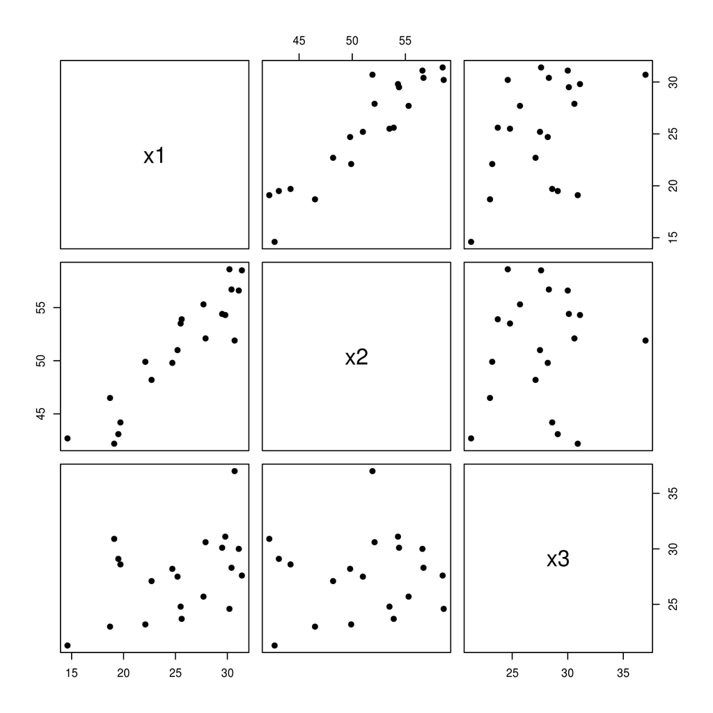

```r
with(.data, pairs(cbind(x1, x2, x3), pch=19))
```

```r
with(.data, cor(cbind(x1, x2, x3)))
```

```
##        x1      x2      x3
## x1 1.0000 0.92384 0.45778
## x2 0.9238 1.00000 0.08467
## x3 0.4578 0.08467 1.00000
```